# Data in R with RStudio

Abner Heredia Bustos, CSCAR

## About this workshop

For beginner R coders that want to understand how to manipulate different types of data. We will use RStudio to learn:

- How R stores and handles different types of data.
- Basic ways to create, import, clean, summarize, and plot data.
- But *NOT* statistical modeling.

## Workshop format

- From 1:00 to 4:45 pm.
- Breaks every 45 minutes.
- A few slides for context and extra information.
- A lot of hands-on coding and live demonstrations.
- All materials will be available after the workshop ends.

## Tips for this workshop

- Coding along with me is the best way to learn.
- Ask questions at any time.
- During exercises, interact with your peers.
- Make sure to type your code in an RStudio script.

## What is CSCAR?

- Full name: Consulting for Statistics, Computing and Analytics Research.
- A unit of the Office of the Vice President of Research (OVPR).
- Guides and trains researchers in data collection, management, and analysis.
- Also helps researchers to use technical software and advanced computing.

## CSCAR is here to help you

- Free, one-hour consultations with full-time statistical consultants.
- GSRAs are available for walk-in consultations Monday through Friday, 9am–5pm (closed on Tuesdays noon–1pm).
- All of our scheduled appointments can be either remote or in-person.

## Contact CSCAR

- To request a consultation: email deskpeople@umich.edu, or fill [this form](https://docs.google.com/forms/d/e/1FAIpQLSei-twcjFkoobUrVwSQTmSxdKKEc1Ub8w5LHmeIZUmTV1wmIg/viewform?pli=1). Or visit cscar.research.umich.edu.
- Self-schedule a consultation with a GSRA using [this link](https://calendar.google.com/calendar/u/0/appointments/AcZssZ1DT776EMK1EGFFmBRyW-FrQrzo35QnU2nIv1E=).
- Address: The University of Michigan, 3560 Rackham, 915 E. Washington St., Ann Arbor, MI 48109-1070.

## Who am I?

- Abner Heredia Bustos, a data science consultant at CSCAR.
- I want to make coding as simple and effortless as possible…
- …which means learning it well from the beginning.

# Why are you trying to learn R?

# Let’s start coding

## Coercion

When adding different data types to the same atomic vector, R follows specific rules to coerce everything to be of the same type.

- If a character string is present in an atomic vector, R will convert all other values to character strings.
- If a vector only contains logicals and numbers, R will convert the logicals to numbers; every `TRUE` becomes a `1`, and every `FALSE` becomes a `0`.
- `NA`s are never coerced automatically.

## Make a histogram

Use the example I showed to you to make a histogram for variable `height`. Bonus: can you color the bars?

Your histogram result should resemble this one:

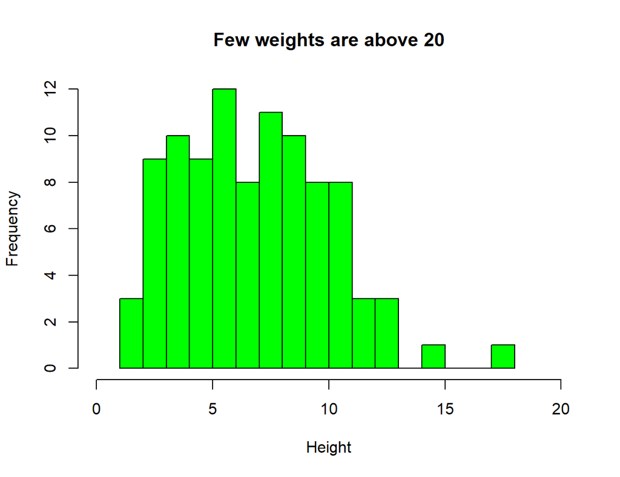

Here is the code for the histogram:

```r
hist(
    flower_df$height,
    breaks = 12,
    xlim = c(0, 20),
    xlab = "Height",
    main = "Few weights are above 20",
    col = "green"
)
```

## Make a boxplot

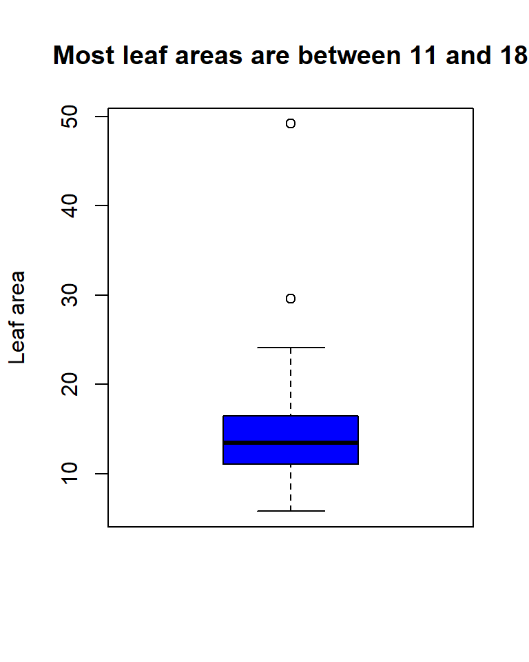

Here is the code for the boxplot.

```r
boxplot(
    flower_df$leaf_area,
    ylab = "Leaf area",
    col = "blue",
    main = "Most leaf areas are between 11 and 18"
)
```

## Make a scatterplot

Use the example I showed to you to make a scatter plot with `height` and `weight`, coloring by nitrogen level. Remember to add a legend to the plot. Your scatter plot should resemble this one:

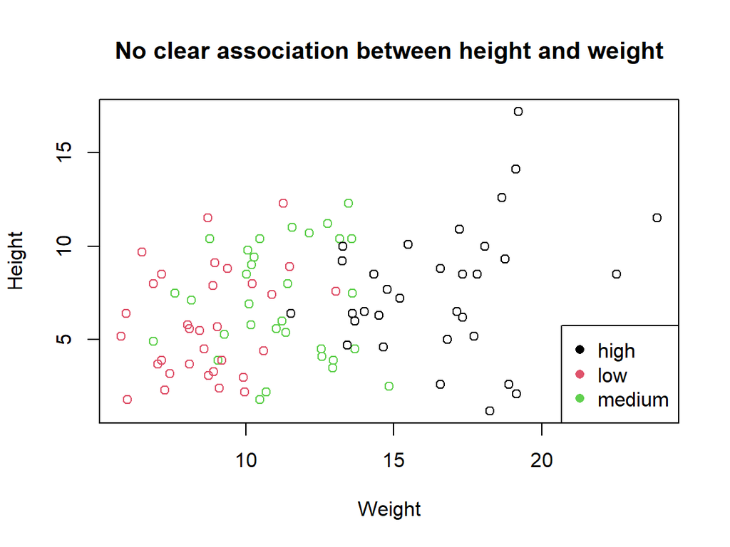

Here is the code for the scatter plot.

```r
plot(
    x = flower_df$weight,
    y = flower_df$height,
    col = flower_df$nitrogen,
    main = "No clear association between height and weight",
    xlab = "Weight",
    ylab = "Height"
)
# Add a legend to the plot
legend(
    x = "bottomright",
    legend = levels(flower_df$nitrogen),
    col = 1:length(levels(flower_df$nitrogen)),
    pch = 16
)
```

## Make a mosaic plot

Use the example I showed to you to make a mosaic plot to visualize how frequently the values of nitrogen and treat combine with each other, but only for flowers with a weight below 10. Your plot should resemble this:

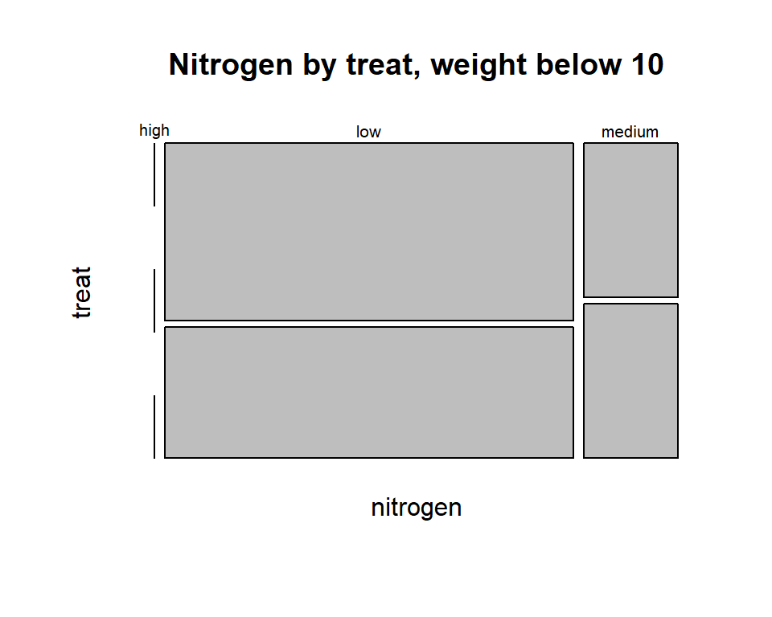

Here is the code for the mosaic plot

```r
nitrogen_by_treat_table = xtabs(
    formula = ~ nitrogen + treat,
    data = flower_df[which(flower_df$weight < 10),]
)
mosaicplot(nitrogen_by_treat_table, main = "Nitrogen by treat, weight below 10")
```